# Project: Wrangle and Analyze Data

##### Note: this document includes the data visualizations, data analyses and insights part for "Wrangle and Analyze Data" project.

## Insights about Data (Visualizations and Analyses)

```python
df = pd.read_csv('twitter_archive_master.csv')
```

### Research Question 1: What are the dog breeds which got top 20 ratings? What are the favorite counts and retweet counts associated with them?

```python
# Take a look at the distributions for the 'rating'
df.describe()
```

|  | tweet_id | rating_numerator | rating_denominator | p1_conf | p2_conf | p3_conf | favorite_count | retweet_count | rating |
| --- | --- | --- | --- | --- | --- | --- | --- | --- | --- |
| count | 1.991000e+03 | 1991.000000 | 1991.000000 | 1991.000000 | 1.991000e+03 | 1.991000e+03 | 1991.000000 | 1991.000000 | 1991.000000 |
| mean | 7.358012e+17 | 12.237961 | 10.532898 | 0.593546 | 1.344798e-01 | 6.030671e-02 | 8641.325465 | 2620.823707 | 1.164872 |
| std | 6.744689e+16 | 41.502410 | 7.326197 | 0.271878 | 1.006249e-01 | 5.089760e-02 | 12681.834564 | 4678.554565 | 4.067361 |
| min | 6.660209e+17 | 0.000000 | 2.000000 | 0.044333 | 1.011300e-08 | 1.740170e-10 | 77.000000 | 11.000000 | 0.000000 |
| 25% | 6.758342e+17 | 10.000000 | 10.000000 | 0.362716 | 5.409535e-02 | 1.622240e-02 | 1855.000000 | 584.500000 | 1.000000 |
| 50% | 7.084699e+17 | 11.000000 | 10.000000 | 0.587372 | 1.175080e-01 | 4.952370e-02 | 3911.000000 | 1258.000000 | 1.100000 |
| 75% | 7.877641e+17 | 12.000000 | 10.000000 | 0.844583 | 1.950575e-01 | 9.164355e-02 | 10760.000000 | 2990.500000 | 1.200000 |
| max | 8.924206e+17 | 1776.000000 | 170.000000 | 1.000000 | 4.880140e-01 | 2.734190e-01 | 162736.000000 | 82813.000000 | 177.600000 |

```python
df[df['rating'] == 0]
```

|  | tweet_id | timestamp | text | rating_numerator | rating_denominator | name | jpg_url | p1 | p1_conf | p1_dog | p2 | p2_conf | p2_dog | p3 | p3_conf | p3_dog | favorite_count | retweet_count | dog_stage | rating |
| --- | --- | --- | --- | --- | --- | --- | --- | --- | --- | --- | --- | --- | --- | --- | --- | --- | --- | --- | --- | --- |
| 234 | 835152434251116546 | 2017-02-24 15:40:31 | When you're so blinded by your systematic plag... | 0.0 | 10 | None | https://pbs.twimg.com/media/C5cOtWVWMAEjO5p.jpg | swing | 0.967066 | False | american_staffordshire_terrier | 0.012731 | True | staffordshire_bullterrier | 0.007039 | True | 23400 | 3206 | None | 0.0 |
| 754 | 746906459439529985 | 2016-06-26 03:22:31 | PUPDATE: can't see any. Even if I could, I cou... | 0.0 | 10 | None | https://pbs.twimg.com/media/Cl2LdofXEAATl7x.jpg | traffic_light | 0.470708 | False | fountain | 0.199776 | False | space_shuttle | 0.064807 | False | 3003 | 312 | None | 0.0 |

```python
# Print out the text where the rating equals minimum - 0
print(df.loc[234]['text'])
print(df.loc[754]['text'])

# They don't look like mistakes.
```

```
When you're so blinded by your systematic plagiarism that you forget what day it is. 0/10 https://t.co/YbEJPkg4Ag
PUPDATE: can't see any. Even if I could, I couldn't reach them to pet. 0/10 much disappointment https://t.co/c7WXaB2nqX
```

```python
# Check out the rating greater than 75% in the distributions.
df[df['rating'] > 2]
```

|  | tweet_id | timestamp | text | rating_numerator | rating_denominator | name | jpg_url | p1 | p1_conf | p1_dog | p2 | p2_conf | p2_dog | p3 | p3_conf | p3_dog | favorite_count | retweet_count | dog_stage | rating |
| --- | --- | --- | --- | --- | --- | --- | --- | --- | --- | --- | --- | --- | --- | --- | --- | --- | --- | --- | --- | --- |
| 384 | 810984652412424192 | 2016-12-19 23:06:23 | Meet Sam. She smiles 24/7 &amp; secretly aspir... | 24.0 | 7 | Sam | https://pbs.twimg.com/media/C0EyPZbXAAAceSc.jpg | golden_retriever | 0.871342 | True | tibetan_mastiff | 0.036708 | True | labrador_retriever | 0.025823 | True | 5645 | 1556 | None | 3.428571 |
| 724 | 749981277374128128 | 2016-07-04 15:00:45 | This is Atticus. He's quite simply America af.... | 1776.0 | 10 | Atticus | https://pbs.twimg.com/media/CmgBZ7kWcAAlzFD.jpg | bow_tie | 0.533941 | False | sunglasses | 0.080822 | False | sunglass | 0.050776 | False | 5328 | 2607 | None | 177.600000 |
| 1715 | 670842764863651840 | 2015-11-29 05:52:33 | After so many requests... here you go.\n\nGood... | 420.0 | 10 | None | https://pbs.twimg.com/media/CU9P717W4AAOlKx.jpg | microphone | 0.096063 | False | accordion | 0.094075 | False | drumstick | 0.061113 | False | 24724 | 8870 | None | 42.000000 |

```python
# Check the 'text'.
print(df.loc[384]['text'])
print()
print(df.loc[724]['text'])
print()
print(df.loc[1715]['text'])

# The 2nd and 3rd ones looks crazy! Let's treat them as outliners.
```

```
Meet Sam. She smiles 24/7 &amp; secretly aspires to be a reindeer.
Keep Sam smiling by clicking and sharing this link:
https://t.co/98tB8y7y7t https://t.co/LouL5vdvxx

This is Atticus. He's quite simply America af. 1776/10 https://t.co/GRXwMxLBkh

After so many requests... here you go.

Good dogg. 420/10 https://t.co/yfAAo1gdeY
```

```python
# Excludes those outliners.
df_no_dog_breed_outliner = df[df['rating'] < 5]
print(len(df_no_dog_breed_outliner))
```

```
1989
```

```python
# Note: some of the dogs are not classified as dogs - per 'p1_dog' column (which is according to the highest predicted probabilities).
# Let's trust the predictions from 'p1' column.
df_true_dogs = df_no_dog_breed_outliner[df_no_dog_breed_outliner['p1_dog'] == True]
len(df_true_dogs)
```

```
1474
```

```python
# Only pick up top 20 ratings
df_high_rating_dog_breed = df_true_dogs.groupby('p1').mean().sort_values(by='rating', ascending=False)[:20]

# Only include interested columns
df_high_rating_dog_breed = df_high_rating_dog_breed[['favorite_count', 'retweet_count', 'rating']]
df_high_rating_dog_breed
```

| p1 | favorite_count | retweet_count | rating |
| --- | --- | --- | --- |
| saluki | 23043.000000 | 4797.500000 | 1.250000 |
| briard | 9028.000000 | 2771.000000 | 1.233333 |
| tibetan_mastiff | 11533.000000 | 3897.250000 | 1.225000 |
| border_terrier | 12945.285714 | 3165.000000 | 1.214286 |
| standard_schnauzer | 1926.000000 | 853.000000 | 1.200000 |
| giant_schnauzer | 11795.666667 | 3571.333333 | 1.200000 |
| silky_terrier | 6962.000000 | 1742.000000 | 1.200000 |
| eskimo_dog | 14119.722222 | 5128.000000 | 1.177778 |
| golden_retriever | 11810.446043 | 3415.647482 | 1.175516 |
| gordon_setter | 5220.000000 | 2317.500000 | 1.175000 |
| irish_setter | 10047.500000 | 3146.750000 | 1.175000 |
| samoyed | 12798.871795 | 4212.589744 | 1.174359 |
| chow | 9634.658537 | 2711.414634 | 1.160976 |
| cardigan | 14557.176471 | 4226.411765 | 1.152941 |
| wire-haired_fox_terrier | 8084.000000 | 2732.000000 | 1.150000 |
| great_pyrenees | 12246.214286 | 4390.357143 | 1.150000 |
| australian_terrier | 10596.500000 | 2880.000000 | 1.150000 |
| kelpie | 9666.636364 | 2317.000000 | 1.145455 |
| pembroke | 10972.409091 | 2999.738636 | 1.144318 |
| norfolk_terrier | 5362.142857 | 1812.714286 | 1.142857 |

```python
high_rating_dog_breeds_s1 = df_high_rating_dog_breed['rating']
high_rating_dog_breeds_s1
```

```
p1
saluki                     1.250000
briard                     1.233333
tibetan_mastiff            1.225000
border_terrier             1.214286
standard_schnauzer         1.200000
giant_schnauzer            1.200000
silky_terrier              1.200000
eskimo_dog                 1.177778
golden_retriever           1.175516
gordon_setter              1.175000
irish_setter               1.175000
samoyed                    1.174359
chow                       1.160976
cardigan                   1.152941
wire-haired_fox_terrier    1.150000
great_pyrenees             1.150000
australian_terrier         1.150000
kelpie                     1.145455
pembroke                   1.144318
norfolk_terrier            1.142857
Name: rating, dtype: float64
```

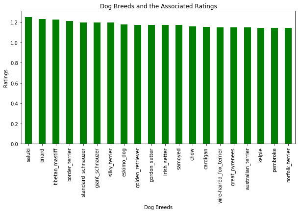

```python
high_rating_dog_breeds_s1.plot(kind='bar', color='green', figsize=(10,5));
plt.xlabel("Dog Breeds")
plt.ylabel("Ratings")
plt.title("Dog Breeds and the Associated Ratings");
```

```python
high_rating_dog_breeds_s2 = df_high_rating_dog_breed['favorite_count']
high_rating_dog_breeds_s2
```

```
p1
saluki                     23043.000000
briard                      9028.000000
tibetan_mastiff            11533.000000
border_terrier             12945.285714
standard_schnauzer          1926.000000
giant_schnauzer            11795.666667
silky_terrier               6962.000000
eskimo_dog                 14119.722222
golden_retriever           11810.446043
gordon_setter               5220.000000
irish_setter               10047.500000
samoyed                    12798.871795
chow                        9634.658537
cardigan                   14557.176471
wire-haired_fox_terrier     8084.000000
great_pyrenees             12246.214286
australian_terrier         10596.500000
kelpie                      9666.636364
pembroke                   10972.409091
norfolk_terrier             5362.142857
Name: favorite_count, dtype: float64
```

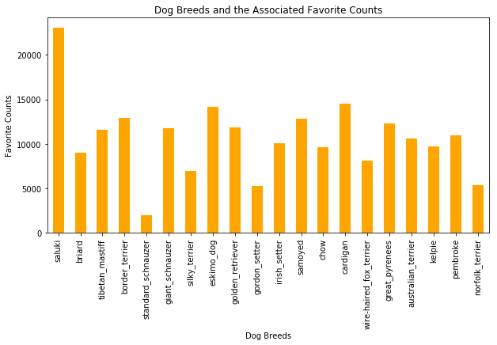

```python
high_rating_dog_breeds_s2.plot(kind='bar', color='orange', figsize=(10,5));
plt.xlabel("Dog Breeds")
plt.ylabel("Favorite Counts")
plt.title("Dog Breeds and the Associated Favorite Counts");
```

```python
high_rating_dog_breeds_s3 = df_high_rating_dog_breed['retweet_count']
high_rating_dog_breeds_s3
```

```
p1
saluki                     4797.500000
briard                     2771.000000
tibetan_mastiff            3897.250000
border_terrier             3165.000000
standard_schnauzer          853.000000
giant_schnauzer            3571.333333
silky_terrier              1742.000000
eskimo_dog                 5128.000000
golden_retriever           3415.647482
gordon_setter              2317.500000
irish_setter               3146.750000
samoyed                    4212.589744
chow                       2711.414634
cardigan                   4226.411765
wire-haired_fox_terrier    2732.000000
great_pyrenees             4390.357143
australian_terrier         2880.000000
kelpie                     2317.000000
pembroke                   2999.738636
norfolk_terrier            1812.714286
Name: retweet_count, dtype: float64
```

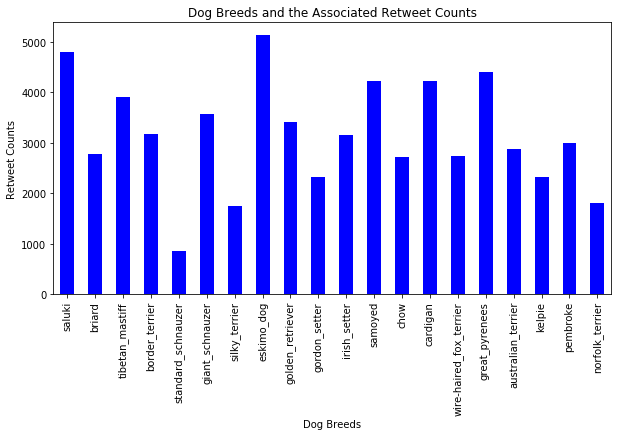

```python
high_rating_dog_breeds_s3.plot(kind='bar', color='blue', figsize=(10,5));
plt.xlabel("Dog Breeds")
plt.ylabel("Retweet Counts")
plt.title("Dog Breeds and the Associated Retweet Counts");
```

**Among the dog breeds which get top 20 ranking in ratings, the top 3 ranking in favorite counts are: saluki, cardigan and eskimo_dog; and the top 3 ranking in retweet counts are: eskimo_dog, saluki and great_pyrenees.**

```python
# Let's see if there any coorelations among ratings, favorite counts and retweet counts
df_subset = df[['rating', 'favorite_count', 'retweet_count']]
df_subset.corr()
```

|  | rating | favorite_count | retweet_count |
| --- | --- | --- | --- |
| rating | 1.000000 | 0.021381 | 0.022159 |
| favorite_count | 0.021381 | 1.000000 | 0.929615 |
| retweet_count | 0.022159 | 0.929615 | 1.000000 |

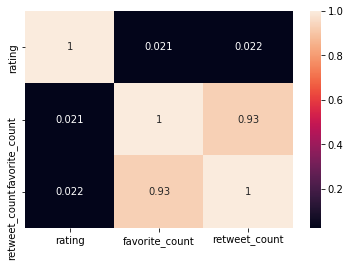

```python
sns.heatmap(df_subset.corr(), annot=True);
```

**Rating does not have high correlations with favorite_count/retweet_count, while favorite_count does have high correlations with retweet_count.**

### Research Question 2: What are the to favored dogs in the past three years?

```python
top_favored_dog_breed_s = df_true_dogs.groupby('p1').favorite_count.mean().sort_values(ascending=False)[:20]
top_favored_dog_breed_s
```

```
p1
saluki                     23043.000000
french_bulldog             18165.560000
afghan_hound               16416.333333
black-and-tan_coonhound    16237.500000
flat-coated_retriever      16042.750000
irish_water_spaniel        15584.333333
standard_poodle            15090.000000
english_springer           14941.888889
cardigan                   14557.176471
leonberg                   14174.666667
eskimo_dog                 14119.722222
basset                     13235.307692
lakeland_terrier           13104.437500
border_terrier             12945.285714
samoyed                    12798.871795
bedlington_terrier         12399.000000
great_pyrenees             12246.214286
mexican_hairless           12066.000000
golden_retriever           11810.446043
giant_schnauzer            11795.666667
Name: favorite_count, dtype: float64
```

```python
# Get top 20 most favored dog breeds
# Make a copy from df_true_dogs first
df_top_favored_dog_breed = df_true_dogs.copy()
top_favored_dog_breed_list = list(top_favored_dog_breed_s.index)

df_top_favored_dog_breed['top_favored'] = False

for i, dog_breed in df_top_favored_dog_breed['p1'].iteritems():
    if dog_breed in top_favored_dog_breed_list:
        df_top_favored_dog_breed.loc[i, 'top_favored'] = True

# Only keep top 20 favored dogs
df_top_favored_dog_breed = df_top_favored_dog_breed[df_top_favored_dog_breed['top_favored'] == True]

# Only keep interested columns
df_top_favored_dog_breed = df_top_favored_dog_breed[['p1', 'favorite_count', 'retweet_count', 'rating', 'top_favored', 'timestamp']]
df_top_favored_dog_breed
# Rename 'p1' to 'dog_breed'
df_top_favored_dog_breed = df_top_favored_dog_breed.rename({'p1': 'dog_breed'}, axis=1)
df_top_favored_dog_breed
```

|  | dog_breed | favorite_count | retweet_count | rating | top_favored | timestamp |
| --- | --- | --- | --- | --- | --- | --- |
| 4 | basset | 39205 | 9074 | 1.20 | True | 2017-07-29 16:00:24 |
| 10 | samoyed | 29882 | 7093 | 1.30 | True | 2017-07-26 00:31:25 |
| 11 | french_bulldog | 27087 | 4818 | 1.30 | True | 2017-07-25 16:11:53 |
| 13 | french_bulldog | 26406 | 4384 | 1.20 | True | 2017-07-25 00:10:02 |
| 14 | golden_retriever | 14725 | 2178 | 1.30 | True | 2017-07-24 17:02:04 |
| 16 | golden_retriever | 28365 | 4359 | 1.20 | True | 2017-07-23 00:22:39 |
| 17 | golden_retriever | 24884 | 4140 | 1.30 | True | 2017-07-22 16:56:37 |
| 19 | french_bulldog | 21187 | 3375 | 1.20 | True | 2017-07-20 16:49:33 |
| 20 | basset | 29411 | 5210 | 1.30 | True | 2017-07-19 16:06:48 |
| 23 | mexican_hairless | 32795 | 10097 | 1.30 | True | 2017-07-18 16:08:03 |
| 24 | samoyed | 29780 | 5771 | 1.20 | True | 2017-07-18 00:07:08 |
| 28 | french_bulldog | 20635 | 3098 | 1.20 | True | 2017-07-15 23:25:31 |
| 39 | golden_retriever | 44725 | 9623 | 1.35 | True | 2017-07-08 00:28:19 |
| 41 | golden_retriever | 36181 | 6456 | 1.30 | True | 2017-07-07 00:17:54 |
| 42 | eskimo_dog | 23320 | 3804 | 1.30 | True | 2017-07-06 15:58:11 |
| 45 | golden_retriever | 43761 | 11239 | 1.30 | True | 2017-07-04 16:01:23 |
| 48 | saluki | 49291 | 10356 | 1.30 | True | 2017-07-03 00:11:11 |
| 49 | samoyed | 48150 | 15485 | 1.40 | True | 2017-07-02 15:32:16 |
| 53 | golden_retriever | 27795 | 6093 | 1.20 | True | 2017-06-29 16:39:47 |
| 56 | basset | 21778 | 3392 | 1.30 | True | 2017-06-28 00:42:13 |
| 58 | english_springer | 103135 | 43024 | 1.30 | True | 2017-06-26 19:07:24 |
| 63 | basset | 7548 | 1250 | 1.30 | True | 2017-06-23 16:00:04 |
| 64 | french_bulldog | 40991 | 6618 | 1.40 | True | 2017-06-23 01:10:23 |
| 66 | basset | 22171 | 3694 | 1.20 | True | 2017-06-21 15:58:08 |
| 67 | saluki | 26732 | 5049 | 1.30 | True | 2017-06-21 00:06:44 |
| 70 | golden_retriever | 18309 | 2326 | 1.30 | True | 2017-06-18 16:57:37 |
| 77 | flat-coated_retriever | 22192 | 3856 | 1.20 | True | 2017-06-12 00:15:36 |
| 78 | cardigan | 33750 | 10160 | 1.30 | True | 2017-06-11 21:18:31 |
| 92 | golden_retriever | 81311 | 25841 | 1.30 | True | 2017-06-01 20:18:38 |
| 104 | eskimo_dog | 15918 | 2477 | 1.20 | True | 2017-05-24 16:44:18 |
| ... | ... | ... | ... | ... | ... | ... |
| 1641 | golden_retriever | 645 | 174 | 1.00 | True | 2015-12-03 21:11:09 |
| 1688 | lakeland_terrier | 955 | 293 | 0.90 | True | 2015-12-01 02:38:04 |
| 1694 | samoyed | 761 | 235 | 1.10 | True | 2015-12-01 00:24:48 |
| 1709 | samoyed | 929 | 411 | 1.00 | True | 2015-11-30 01:28:28 |
| 1724 | basset | 1138 | 275 | 1.00 | True | 2015-11-29 03:50:10 |
| 1751 | english_springer | 6760 | 2010 | 1.00 | True | 2015-11-28 03:31:48 |
| 1765 | english_springer | 747 | 274 | 1.20 | True | 2015-11-27 22:51:19 |
| 1796 | eskimo_dog | 514 | 152 | 1.00 | True | 2015-11-25 19:25:57 |
| 1805 | basset | 468 | 160 | 1.00 | True | 2015-11-25 04:11:57 |
| 1806 | golden_retriever | 624 | 231 | 1.00 | True | 2015-11-25 03:56:01 |
| 1812 | golden_retriever | 578 | 118 | 1.30 | True | 2015-11-25 01:30:16 |
| 1814 | golden_retriever | 1196 | 409 | 0.80 | True | 2015-11-24 18:11:04 |
| 1827 | golden_retriever | 802 | 354 | 1.20 | True | 2015-11-24 02:29:49 |
| 1828 | basset | 1307 | 588 | 1.10 | True | 2015-11-24 02:13:25 |
| 1831 | standard_poodle | 266 | 59 | 0.90 | True | 2015-11-23 23:23:31 |
| 1835 | golden_retriever | 457 | 169 | 1.10 | True | 2015-11-23 18:02:38 |
| 1846 | french_bulldog | 320 | 118 | 0.90 | True | 2015-11-23 03:09:00 |
| 1854 | lakeland_terrier | 252 | 77 | 0.80 | True | 2015-11-22 21:13:35 |
| 1858 | standard_poodle | 430 | 239 | 0.90 | True | 2015-11-22 17:40:27 |
| 1863 | golden_retriever | 505 | 138 | 1.10 | True | 2015-11-22 04:33:59 |
| 1890 | flat-coated_retriever | 329 | 97 | 1.20 | True | 2015-11-20 20:25:43 |
| 1902 | golden_retriever | 464 | 239 | 1.00 | True | 2015-11-20 02:32:25 |
| 1918 | golden_retriever | 489 | 242 | 0.90 | True | 2015-11-19 05:24:37 |
| 1922 | golden_retriever | 14274 | 6205 | 1.00 | True | 2015-11-19 03:29:07 |
| 1926 | giant_schnauzer | 220 | 89 | 1.00 | True | 2015-11-19 02:43:18 |
| 1928 | golden_retriever | 254 | 62 | 1.10 | True | 2015-11-19 01:59:39 |
| 1936 | golden_retriever | 182 | 50 | 1.20 | True | 2015-11-18 18:17:59 |
| 1962 | black-and-tan_coonhound | 105 | 39 | 0.70 | True | 2015-11-17 00:06:54 |
| 1967 | golden_retriever | 284 | 132 | 1.00 | True | 2015-11-16 20:01:42 |
| 1980 | golden_retriever | 461 | 212 | 1.00 | True | 2015-11-16 01:22:45 |

339 rows × 6 columns

```python
# Divide timestamps into years for easier analyzing
df_top_favored_dog_breed['year'] = 'Year 2015'

def get_tweet_year(row):
    if row['timestamp'] >= '2015-01-01' and row['timestamp'] < '2016-01-01':
        row['year'] = 'Year 2015'
    elif row['timestamp'] >= '2016-01-01' and row['timestamp'] < '2017-01-01':
        row['year'] = 'Year 2016'
    elif row['timestamp'] >= '2017-01-01' and row['timestamp'] < '2018-01-01':
        row['year'] = 'Year 2017'

    return row

df_top_favored_dog_breed = df_top_favored_dog_breed.apply(get_tweet_year, axis=1)
df_top_favored_dog_breed = df_top_favored_dog_breed.drop('top_favored', axis=1)
df_top_favored_dog_breed
```

|  | dog_breed | favorite_count | retweet_count | rating | timestamp | year |
| --- | --- | --- | --- | --- | --- | --- |
| 4 | basset | 39205 | 9074 | 1.20 | 2017-07-29 16:00:24 | Year 2017 |
| 10 | samoyed | 29882 | 7093 | 1.30 | 2017-07-26 00:31:25 | Year 2017 |
| 11 | french_bulldog | 27087 | 4818 | 1.30 | 2017-07-25 16:11:53 | Year 2017 |
| 13 | french_bulldog | 26406 | 4384 | 1.20 | 2017-07-25 00:10:02 | Year 2017 |
| 14 | golden_retriever | 14725 | 2178 | 1.30 | 2017-07-24 17:02:04 | Year 2017 |
| 16 | golden_retriever | 28365 | 4359 | 1.20 | 2017-07-23 00:22:39 | Year 2017 |
| 17 | golden_retriever | 24884 | 4140 | 1.30 | 2017-07-22 16:56:37 | Year 2017 |
| 19 | french_bulldog | 21187 | 3375 | 1.20 | 2017-07-20 16:49:33 | Year 2017 |
| 20 | basset | 29411 | 5210 | 1.30 | 2017-07-19 16:06:48 | Year 2017 |
| 23 | mexican_hairless | 32795 | 10097 | 1.30 | 2017-07-18 16:08:03 | Year 2017 |
| 24 | samoyed | 29780 | 5771 | 1.20 | 2017-07-18 00:07:08 | Year 2017 |
| 28 | french_bulldog | 20635 | 3098 | 1.20 | 2017-07-15 23:25:31 | Year 2017 |
| 39 | golden_retriever | 44725 | 9623 | 1.35 | 2017-07-08 00:28:19 | Year 2017 |
| 41 | golden_retriever | 36181 | 6456 | 1.30 | 2017-07-07 00:17:54 | Year 2017 |
| 42 | eskimo_dog | 23320 | 3804 | 1.30 | 2017-07-06 15:58:11 | Year 2017 |
| 45 | golden_retriever | 43761 | 11239 | 1.30 | 2017-07-04 16:01:23 | Year 2017 |
| 48 | saluki | 49291 | 10356 | 1.30 | 2017-07-03 00:11:11 | Year 2017 |
| 49 | samoyed | 48150 | 15485 | 1.40 | 2017-07-02 15:32:16 | Year 2017 |
| 53 | golden_retriever | 27795 | 6093 | 1.20 | 2017-06-29 16:39:47 | Year 2017 |
| 56 | basset | 21778 | 3392 | 1.30 | 2017-06-28 00:42:13 | Year 2017 |
| 58 | english_springer | 103135 | 43024 | 1.30 | 2017-06-26 19:07:24 | Year 2017 |
| 63 | basset | 7548 | 1250 | 1.30 | 2017-06-23 16:00:04 | Year 2017 |
| 64 | french_bulldog | 40991 | 6618 | 1.40 | 2017-06-23 01:10:23 | Year 2017 |
| 66 | basset | 22171 | 3694 | 1.20 | 2017-06-21 15:58:08 | Year 2017 |
| 67 | saluki | 26732 | 5049 | 1.30 | 2017-06-21 00:06:44 | Year 2017 |
| 70 | golden_retriever | 18309 | 2326 | 1.30 | 2017-06-18 16:57:37 | Year 2017 |
| 77 | flat-coated_retriever | 22192 | 3856 | 1.20 | 2017-06-12 00:15:36 | Year 2017 |
| 78 | cardigan | 33750 | 10160 | 1.30 | 2017-06-11 21:18:31 | Year 2017 |
| 92 | golden_retriever | 81311 | 25841 | 1.30 | 2017-06-01 20:18:38 | Year 2017 |
| 104 | eskimo_dog | 15918 | 2477 | 1.20 | 2017-05-24 16:44:18 | Year 2017 |
| ... | ... | ... | ... | ... | ... | ... |
| 1641 | golden_retriever | 645 | 174 | 1.00 | 2015-12-03 21:11:09 | Year 2015 |
| 1688 | lakeland_terrier | 955 | 293 | 0.90 | 2015-12-01 02:38:04 | Year 2015 |
| 1694 | samoyed | 761 | 235 | 1.10 | 2015-12-01 00:24:48 | Year 2015 |
| 1709 | samoyed | 929 | 411 | 1.00 | 2015-11-30 01:28:28 | Year 2015 |
| 1724 | basset | 1138 | 275 | 1.00 | 2015-11-29 03:50:10 | Year 2015 |
| 1751 | english_springer | 6760 | 2010 | 1.00 | 2015-11-28 03:31:48 | Year 2015 |
| 1765 | english_springer | 747 | 274 | 1.20 | 2015-11-27 22:51:19 | Year 2015 |
| 1796 | eskimo_dog | 514 | 152 | 1.00 | 2015-11-25 19:25:57 | Year 2015 |
| 1805 | basset | 468 | 160 | 1.00 | 2015-11-25 04:11:57 | Year 2015 |
| 1806 | golden_retriever | 624 | 231 | 1.00 | 2015-11-25 03:56:01 | Year 2015 |
| 1812 | golden_retriever | 578 | 118 | 1.30 | 2015-11-25 01:30:16 | Year 2015 |
| 1814 | golden_retriever | 1196 | 409 | 0.80 | 2015-11-24 18:11:04 | Year 2015 |
| 1827 | golden_retriever | 802 | 354 | 1.20 | 2015-11-24 02:29:49 | Year 2015 |
| 1828 | basset | 1307 | 588 | 1.10 | 2015-11-24 02:13:25 | Year 2015 |
| 1831 | standard_poodle | 266 | 59 | 0.90 | 2015-11-23 23:23:31 | Year 2015 |
| 1835 | golden_retriever | 457 | 169 | 1.10 | 2015-11-23 18:02:38 | Year 2015 |
| 1846 | french_bulldog | 320 | 118 | 0.90 | 2015-11-23 03:09:00 | Year 2015 |
| 1854 | lakeland_terrier | 252 | 77 | 0.80 | 2015-11-22 21:13:35 | Year 2015 |
| 1858 | standard_poodle | 430 | 239 | 0.90 | 2015-11-22 17:40:27 | Year 2015 |
| 1863 | golden_retriever | 505 | 138 | 1.10 | 2015-11-22 04:33:59 | Year 2015 |
| 1890 | flat-coated_retriever | 329 | 97 | 1.20 | 2015-11-20 20:25:43 | Year 2015 |
| 1902 | golden_retriever | 464 | 239 | 1.00 | 2015-11-20 02:32:25 | Year 2015 |
| 1918 | golden_retriever | 489 | 242 | 0.90 | 2015-11-19 05:24:37 | Year 2015 |
| 1922 | golden_retriever | 14274 | 6205 | 1.00 | 2015-11-19 03:29:07 | Year 2015 |
| 1926 | giant_schnauzer | 220 | 89 | 1.00 | 2015-11-19 02:43:18 | Year 2015 |
| 1928 | golden_retriever | 254 | 62 | 1.10 | 2015-11-19 01:59:39 | Year 2015 |
| 1936 | golden_retriever | 182 | 50 | 1.20 | 2015-11-18 18:17:59 | Year 2015 |
| 1962 | black-and-tan_coonhound | 105 | 39 | 0.70 | 2015-11-17 00:06:54 | Year 2015 |
| 1967 | golden_retriever | 284 | 132 | 1.00 | 2015-11-16 20:01:42 | Year 2015 |
| 1980 | golden_retriever | 461 | 212 | 1.00 | 2015-11-16 01:22:45 | Year 2015 |

339 rows × 6 columns

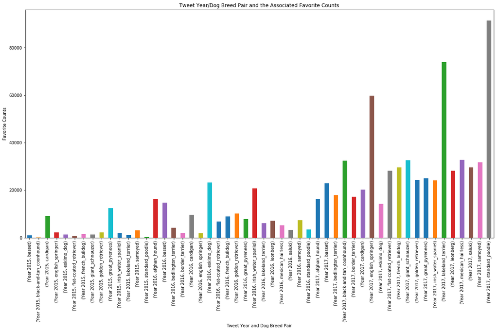

```python
# Let's plot groupby 'year' and dog_breed' and get the mean on favorite counts.
df_top_favored_dog_breed.groupby(['year','dog_breed']).favorite_count.mean().plot(kind='bar', figsize=(20, 10));
plt.xlabel("Tweet Year and Dog Breed Pair")
plt.ylabel("Favorite Counts")
plt.title("Tweet Year/Dog Breed Pair and the Associated Favorite Counts");
```

```python
df_dog_stage = df.copy()

df_dog_stage['dog_stage'] = df_dog_stage['dog_stage'].apply(lambda x: 'other' if x == 'None' else x)
df_dog_stage
```

[output not shown]

1991 rows × 20 columns

### Research Question 3: Among different dog stages, which one get highest rating? Which one is most favored? And which one get most retweet counts?

```python
other_mask = (df_dog_stage['dog_stage'] == 'other')
pupper_mask = (df_dog_stage['dog_stage'] == 'pupper')
doggo_mask = (df_dog_stage['dog_stage'] == 'doggo')
puppo_mask = (df_dog_stage['dog_stage'] == 'puppo')
floofer_mask = (df_dog_stage['dog_stage'] == 'floofer')
```

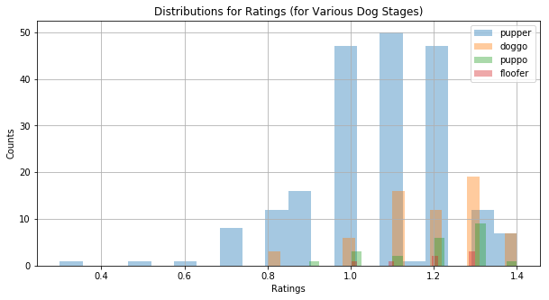

```python
df_dog_stage.rating[pupper_mask].hist(label='pupper', alpha=0.4, bins=20, figsize=(10,5));
df_dog_stage.rating[doggo_mask].hist(label='doggo', alpha=0.4, bins=20, figsize=(10,5));
df_dog_stage.rating[puppo_mask].hist(label='puppo', alpha=0.4, bins=20, figsize=(10,5));
df_dog_stage.rating[floofer_mask].hist(label='floofer', alpha=0.4, bins=20, figsize=(10,5));
plt.xlabel("Ratings")
plt.ylabel("Counts")
plt.title("Distributions for Ratings (for Various Dog Stages)")
plt.legend();
```

**Looks like 'doggo' and 'puppo' get higher ratings!**

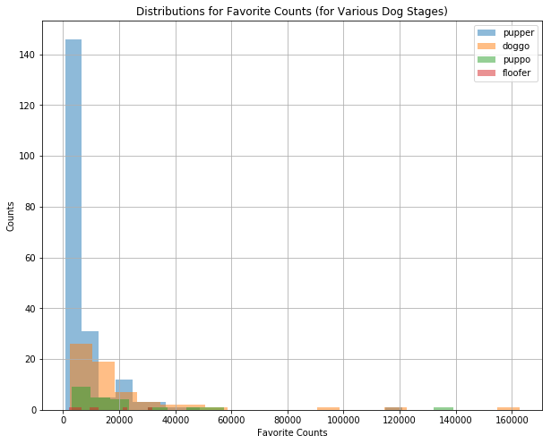

```python
df_dog_stage.favorite_count[pupper_mask].hist(label='pupper', alpha=0.5, bins=20, figsize=(10,8));
df_dog_stage.favorite_count[doggo_mask].hist(label='doggo', alpha=0.5, bins=20, figsize=(10,8));
df_dog_stage.favorite_count[puppo_mask].hist(label='puppo', alpha=0.5, bins=20, figsize=(10,8));
df_dog_stage.favorite_count[floofer_mask].hist(label='floofer', alpha=0.5, bins=20, figsize=(10,8));
plt.xlabel("Favorite Counts")
plt.ylabel("Counts")
plt.title("Distributions for Favorite Counts (for Various Dog Stages)")
plt.legend();
```

**Looks like higher favorite counts go to 'doggo' and 'puppo'!**

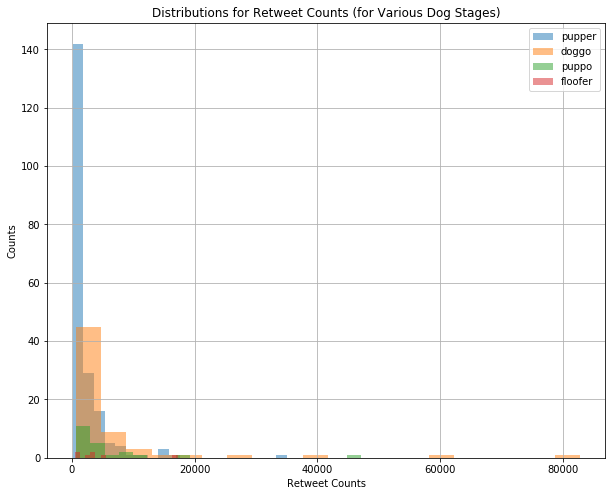

```python
df_dog_stage.retweet_count[pupper_mask].hist(label='pupper', alpha=0.5, bins=20, figsize=(10,8));
df_dog_stage.retweet_count[doggo_mask].hist(label='doggo', alpha=0.5, bins=20, figsize=(10,8));
df_dog_stage.retweet_count[puppo_mask].hist(label='puppo', alpha=0.5, bins=20, figsize=(10,8));
df_dog_stage.retweet_count[floofer_mask].hist(label='floofer', alpha=0.5, bins=20, figsize=(10,8));
plt.xlabel("Retweet Counts")
plt.ylabel("Counts")
plt.title("Distributions for Retweet Counts (for Various Dog Stages)")
plt.legend();
```

**Looks like 'doggle' also get higher retweet counts!**

```python
df_dog_stage_groups = df_dog_stage.query('(dog_stage != "doggo,pupper") and (dog_stage != "doggo,floofer") and (dog_stage != "doggo,puppo")')
```

```python
dog_stage_g1 = df_dog_stage_groups.groupby('dog_stage')['rating'].mean()
dog_stage_g1
```

```
dog_stage
doggo      1.188889
floofer    1.200000
other      1.175866
pupper     1.063680
puppo      1.200000
Name: rating, dtype: float64
```

```python
dog_stage_g2 = df_dog_stage_groups.groupby('dog_stage')['favorite_count'].mean()
dog_stage_g2
```

```
dog_stage
doggo      19902.904762
floofer    12557.285714
other       8190.202967
pupper      6941.231527
puppo      21597.590909
Name: favorite_count, dtype: float64
```

```python
dog_stage_g3 = df_dog_stage_groups.groupby('dog_stage')['retweet_count'].mean()
dog_stage_g3
```

```
dog_stage
doggo      6992.539683
floofer    4635.714286
other      2433.221365
pupper     2223.768473
puppo      6214.500000
Name: retweet_count, dtype: float64
```

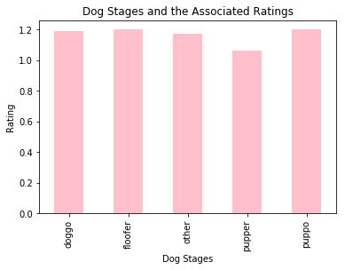

```python
dog_stage_g1.plot(kind='bar', color='pink');
plt.xlabel("Dog Stages")
plt.ylabel("Rating")
plt.title("Dog Stages and the Associated Ratings");
```

**'Puppo' and 'floofer' get highest ratings!**

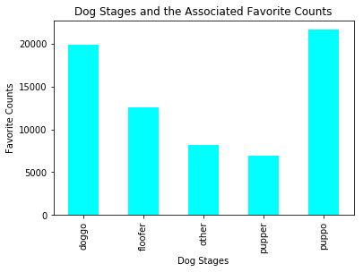

```python
dog_stage_g2.plot(kind='bar', color='cyan');
plt.xlabel("Dog Stages")
plt.ylabel("Favorite Counts")
plt.title("Dog Stages and the Associated Favorite Counts");
```

**'Puppo' and 'doggo' get top 2 favorit counts!**

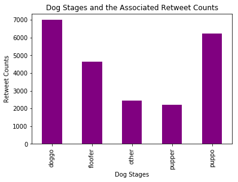

```python
dog_stage_g3.plot(kind='bar', color='purple');
plt.xlabel("Dog Stages")
plt.ylabel("Retweet Counts")
plt.title("Dog Stages and the Associated Retweet Counts");
```

**'Doggo' and 'puppo' get top 2 retweet counts!**

### Insights:

#### Insights 1:

> - The dog breeds get top 3 rankings in rating are: saluki, briard, and tibetan_mastiff.
> - Among the dog breeds which get top 20 ranking in ratings, the top 3 ranking in favorite counts are: saluki, cardigan and eskimo_dog; and the top 3 ranking in retweet counts are: eskimo_dog, saluki and great_pyrenees.
> - Rating does not have high correlations with favorite_count/retweet_count, while favorite_count does have high correlations with retweet_count.

#### Insights 3:

Among different dog stages:

> - Puppo and floofer got top 2 ratings.
> - Puppo and doggo got top 2 favorite counts.
> - Doggo and puppo got top 2 retweet counts.
> - Lowest rating/favirote counts/retweet counts goes to pupper. Dog in other stages (might be older or bigger) get 2nd lowest rating/counts.